# Mass Tests Condensed

Garrick Bruening

# 1 Preferred Experiment

## 1.1 Across prefs

## 1.2 Movement Duration

Table 1.1: Movement duration linear models.

| Duration | Linear Estimate | P-Value | Std Error |
| --- | --- | --- | --- |
| Circle | 3.398e-02 | 0.000e+00 | 1.018e-03 |
| Pilot | 4.066e-02 | 0.000e+00 | 5.330e-04 |
| Arc | 3.665e-02 | 0.000e+00 | 9.492e-04 |
| All | 3.764e-02 | 0.000e+00 | 4.590e-04 |

Table 1.1: Movement duration average values (s)

| Effective Mass (kg) | 2a | 2b | 2c |
| --- | --- | --- | --- |
| 2.5 | 0.764±0.038 | 0.823±0.031 | 0.632±0.036 |
| 3.8 | 0.83±0.041 | 0.881±0.033 | 0.703±0.034 |
| 4.7 | 0.856±0.042 | 0.905±0.034 | 0.741±0.043 |
| 6.1 | 0.89±0.043 | 0.959±0.036 | 0.781±0.048 |

This next stat output shows the a LME with movedur ~ target + eff_mass*exp + (1|subj).

```
##
##   Simultaneous Tests for General Linear Hypotheses
##
## Fit: lmer(formula = movedur ~ factor(targetnum) + eff_mass * factor(exp) +
##     (1 | subj), data = prefpilot)
##
## Linear Hypotheses:
##                                   Estimate Std. Error z value Pr(>|z|)
## (Intercept) == 0                 0.7201709  0.0296551  24.285  < 2e-16 ***
## factor(targetnum)2 == 0         -0.0653049  0.0017152 -38.075  < 2e-16 ***
## factor(targetnum)3 == 0         -0.0067108  0.0017313  -3.876 0.000106 ***
## factor(targetnum)4 == 0         -0.0394681  0.0017155 -23.007  < 2e-16 ***
## eff_mass == 0                    0.0339780  0.0008742  38.866  < 2e-16 ***
## factor(exp)pilot == 0           -0.1469007  0.0382529  -3.840 0.000123 ***
## factor(exp)smallt == 0           0.0442074  0.0418978   1.055 0.291369
## eff_mass:factor(exp)pilot == 0   0.0067011  0.0011208   5.979 2.25e-09 ***
## eff_mass:factor(exp)smallt == 0  0.0026912  0.0012137   2.217 0.026598 *
## ---
## Signif. codes:  0 '***' 0.001 '**' 0.01 '*' 0.05 '.' 0.1 ' ' 1
## (Univariate p values reported)
```

There is an overall effect of mass on movement duration (slope = 3.398e-02, p = 0.000e+00).

Experiment 2b movement duration is not different from 2a (p = 2.914e-01).

Experiment 2c movement duration is significantly lower than 2a (slope = -1.469e-01, p = 1.229e-04).

The interesting thing with these are the interaction effects.

Experiment 2b movement duration increases with mass more than experiment 2a (slope = 2.691e-03, p = 2.660e-02).

Experiment 2c movement duration increases with mass more than experiment 2a (slope = 6.701e-03, p = 2.245e-09).

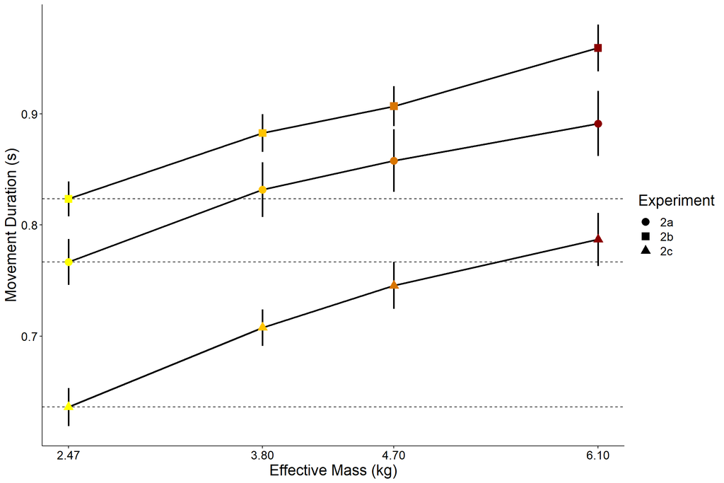

Figure 1.1: Movement Duration by experiment.

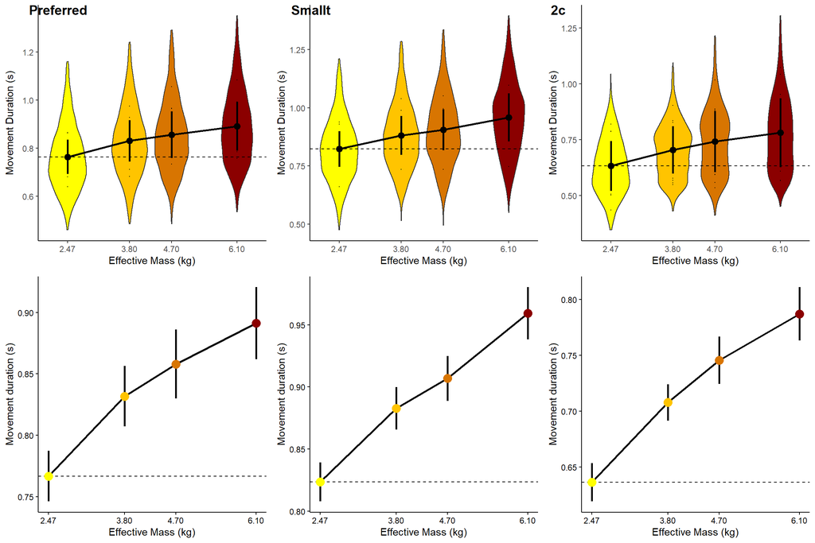

Figure 1.2: Movement duration broken up by experiment.

## 1.3 Peak Velocity

Table 1.2: Peak Velocity linear models.

| Velocity | Linear Estimate | P-Value | Std Error |
| --- | --- | --- | --- |
| Circle | -1.364e-02 | 0.000e+00 | 3.095e-04 |
| Pilot | -2.052e-02 | 0.000e+00 | 3.331e-04 |
| Arc | -1.187e-02 | 0.000e+00 | 2.224e-04 |
| All | -1.608e-02 | 0.000e+00 | 1.810e-04 |

Table 1.2: Peak Velocity average values (m/s)

| Effective Mass (kg) | 2a | 2b | 2c |
| --- | --- | --- | --- |
| 2.5 | 0.264±0.076 | 0.23±0.066 | 0.393±0.093 |
| 3.8 | 0.235±0.068 | 0.208±0.06 | 0.347±0.082 |
| 4.7 | 0.225±0.065 | 0.201±0.058 | 0.334±0.079 |
| 6.1 | 0.213±0.061 | 0.185±0.054 | 0.315±0.074 |

```
##
##   Simultaneous Tests for General Linear Hypotheses
##
## Fit: lmer(formula = peakvel_target ~ factor(targetnum) + eff_mass +
##     eff_mass * factor(exp) + (1 | subj), data = prefpilot)
##
## Linear Hypotheses:
##                                   Estimate Std. Error z value Pr(>|z|)
## (Intercept) == 0                 0.2779341  0.0173622  16.008  < 2e-16 ***
## factor(targetnum)2 == 0          0.0204180  0.0006711  30.425  < 2e-16 ***
## factor(targetnum)3 == 0          0.0100581  0.0006774  14.847  < 2e-16 ***
## factor(targetnum)4 == 0          0.0234736  0.0006712  34.971  < 2e-16 ***
## eff_mass == 0                   -0.0136629  0.0003421 -39.942  < 2e-16 ***
## factor(exp)pilot == 0            0.1426530  0.0224063   6.367 1.93e-10 ***
## factor(exp)smallt == 0          -0.0349980  0.0245432  -1.426 0.153875
## eff_mass:factor(exp)pilot == 0  -0.0068836  0.0004385 -15.697  < 2e-16 ***
## eff_mass:factor(exp)smallt == 0  0.0017847  0.0004749   3.758 0.000171 ***
## ---
## Signif. codes:  0 '***' 0.001 '**' 0.01 '*' 0.05 '.' 0.1 ' ' 1
## (Univariate p values reported)
```

There is an overall effect of mass on peak velocity (slope = -1.366e-02, p = 0.000e+00).

Experiment 2b peak velocity is not different from 2a (p = 1.539e-01).

Experiment 2c peak velocity is significantly greater than 2a (slope = 1.427e-01, p = 1.932e-10).

The interesting thing with these are the interaction effects.

Experiment 2b peak velocity increases with mass more than experiment 2a (slope = 1.785e-03, p = 1.712e-04).

Experiment 2c peak velocity decreases with mass more than experiment 2a (slope = -6.884e-03, p = 0.000e+00).

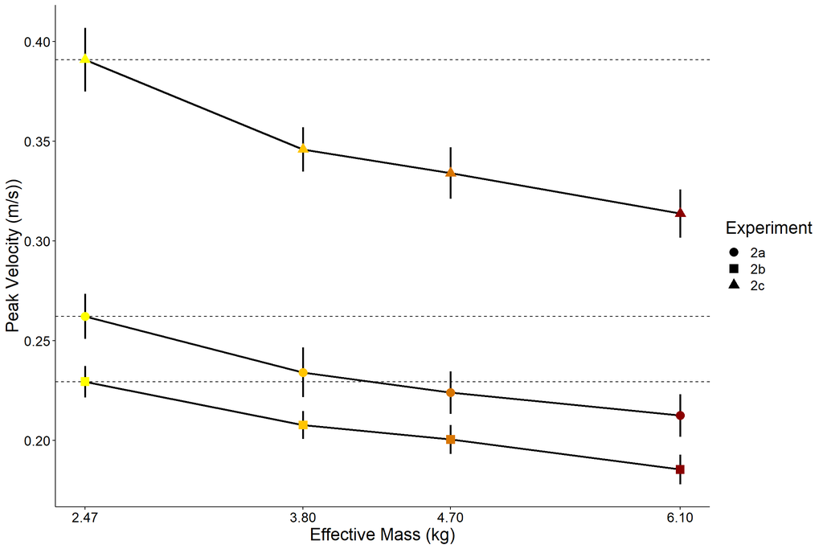

Figure 1.3: Peak Velocity by experiment.

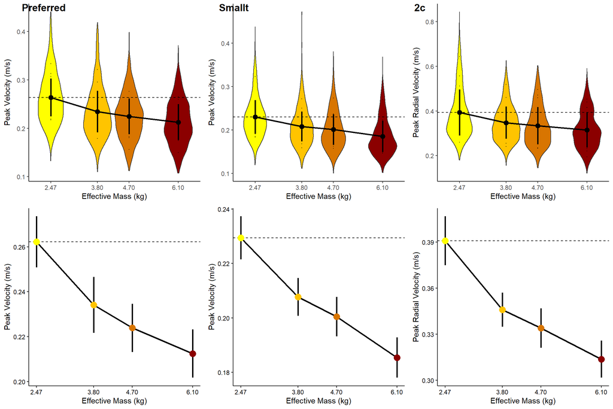

Figure 1.4: Peak velocity broken by experiment.

## 1.4 Reaction Time

Table 1.3: Reaction Time linear models.

| Reaction Time | Linear Estimate | P-Value | Std Error |
| --- | --- | --- | --- |
| Circle | 4.645e-03 | 0.000e+00 | 3.305e-04 |
| Pilot | 5.313e-03 | 0.000e+00 | 3.011e-04 |
| Arc | 6.401e-03 | 0.000e+00 | 3.341e-04 |
| All | 5.461e-03 | 0.000e+00 | 1.868e-04 |

| Effective Mass (kg) | 2a | 2b | 2c |
| --- | --- | --- | --- |
| 2.5 | 0.18±0.012 | 0.204±0.013 | 0.198±0.012 |
| 3.8 | 0.186±0.013 | 0.215±0.013 | 0.207±0.011 |
| 4.7 | 0.189±0.013 | 0.219±0.013 | 0.212±0.012 |
| 6.1 | 0.197±0.013 | 0.228±0.013 | 0.216±0.011 |

```
##
##   Simultaneous Tests for General Linear Hypotheses
##
## Fit: lmer(formula = reaction_tanv ~ factor(targetnum) + eff_mass +
##     eff_mass * factor(exp) + (1 | subj), data = prefpilot)
##
## Linear Hypotheses:
##                                   Estimate Std. Error z value Pr(>|z|)
## (Intercept) == 0                 0.1775709  0.0062008  28.637  < 2e-16 ***
## factor(targetnum)2 == 0         -0.0135552  0.0006985 -19.405  < 2e-16 ***
## factor(targetnum)3 == 0         -0.0002042  0.0007051  -0.290 0.772144
## factor(targetnum)4 == 0         -0.0204404  0.0006987 -29.256  < 2e-16 ***
## eff_mass == 0                    0.0046670  0.0003561  13.108  < 2e-16 ***
## factor(exp)pilot == 0            0.0169967  0.0079800   2.130 0.033179 *
## factor(exp)smallt == 0           0.0197597  0.0087367   2.262 0.023717 *
## eff_mass:factor(exp)pilot == 0   0.0006478  0.0004565   1.419 0.155876
## eff_mass:factor(exp)smallt == 0  0.0017406  0.0004943   3.521 0.000429 ***
## ---
## Signif. codes:  0 '***' 0.001 '**' 0.01 '*' 0.05 '.' 0.1 ' ' 1
## (Univariate p values reported)
```

There is an overall effect of mass on reaction_time (slope = 4.667e-03, p = 0.000e+00).

Experiment 2b reaction_time is significantly greater than 2a (slope = 1.976e-02, p = 2.372e-02).

Experiment 2c reaction_time is significantly greater than 2a (slope = 1.700e-02, p = 3.318e-02).

The interesting thing with these are the interaction effects.

Experiment 2b reaction_time increases with mass more than experiment 2a (slope = 1.741e-03, p = 4.294e-04).

Experiment 2c reaction_time did NOT change with mass more than 2a. (p = 1.559e-01).

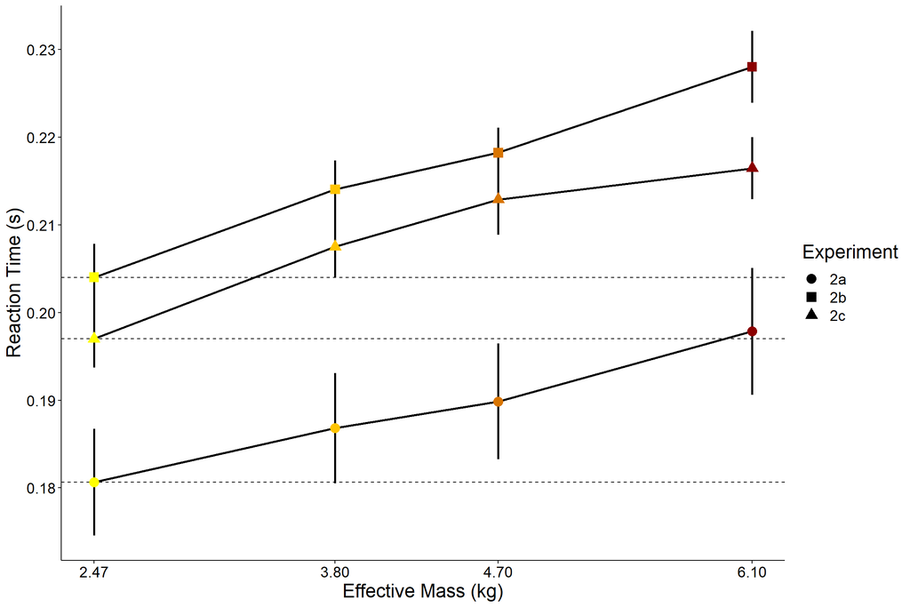

Figure 1.5: Reaction Time by experiment.

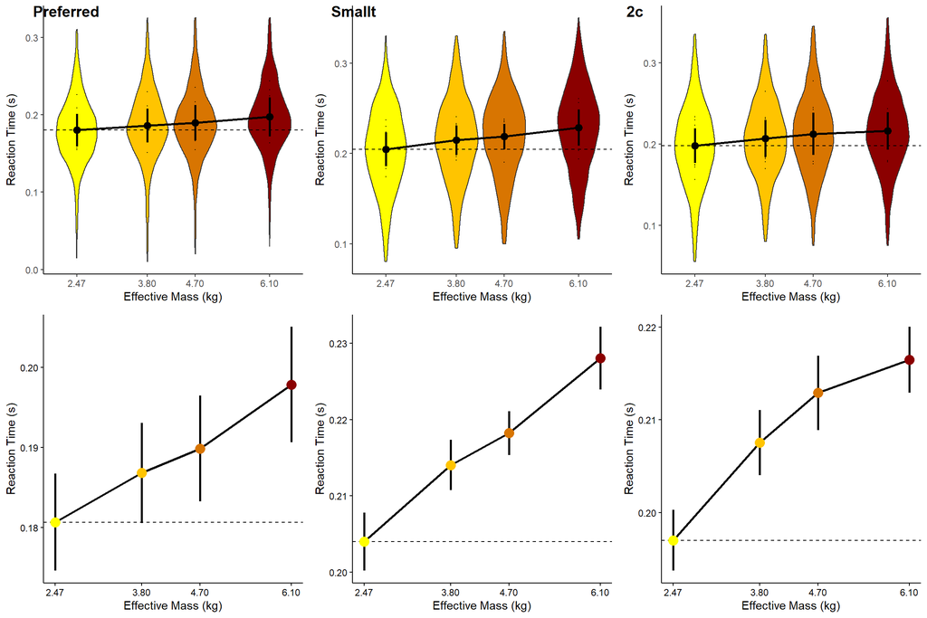

Figure 1.6: Reaction Time broken by experiment.

### 1.4.1 Reaction Time Algorithm

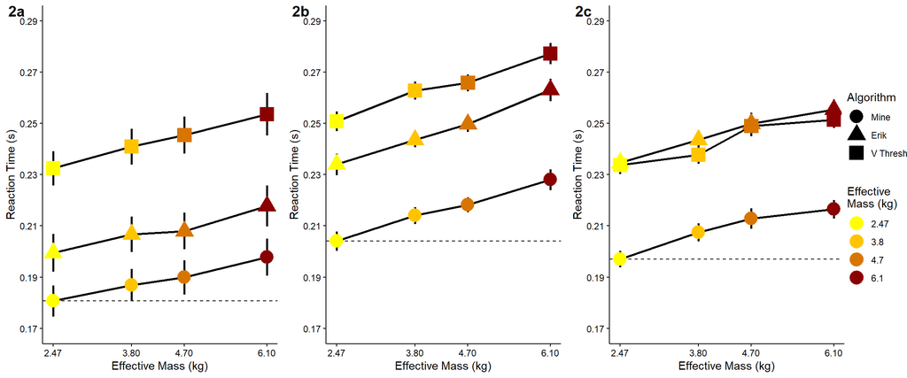

Figure 1.7: Reaction Time Algorithm method.

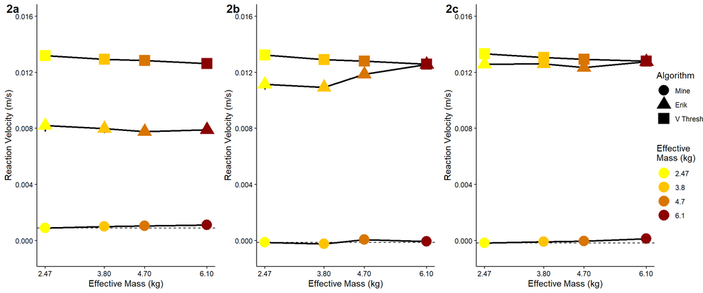

Figure 1.8: Reaction Velocity Algorithm method.

## 1.5 Endpoint Error

Table 1.4: Miss Distance linear models.

| Miss Distance | Linear Estimate | P-Value | Std Error |
| --- | --- | --- | --- |
| Circle | -3.925e-05 | 1.486e-01 | 2.717e-05 |
| Pilot | 1.023e-03 | 0.000e+00 | 9.391e-05 |
| Arc | -1.389e-04 | 8.788e-05 | 3.541e-05 |
| All | 3.740e-04 | 0.000e+00 | 4.370e-05 |

Table 1.4: Miss Distance average values (cm)

| Effective Mass (kg) | 2a | 2b | 2c |
| --- | --- | --- | --- |
| 2.5 | 0.623±0.094 | 0.887±0.141 | 12.712±0.409 |
| 3.8 | 0.611±0.096 | 0.831±0.129 | 13.029±0.423 |
| 4.7 | 0.608±0.099 | 0.857±0.138 | 13.107±0.419 |
| 6.1 | 0.605±0.098 | 0.832±0.133 | 13.08±0.415 |

This next stat output shows the a LME with miss_dist ~ target + eff_mass*exp + (1|subj).

```
##
##   Simultaneous Tests for General Linear Hypotheses
##
## Fit: lmer(formula = miss_dist ~ factor(targetnum) + eff_mass + eff_mass *
##     factor(exp) + (1 | subj), data = prefpilot)
##
## Linear Hypotheses:
##                                   Estimate Std. Error z value Pr(>|z|)
## (Intercept) == 0                 7.135e-03  2.131e-03   3.348 0.000814 ***
## factor(targetnum)2 == 0         -3.762e-03  1.629e-04 -23.091  < 2e-16 ***
## factor(targetnum)3 == 0          1.503e-03  1.645e-04   9.138  < 2e-16 ***
## factor(targetnum)4 == 0         -3.755e-04  1.630e-04  -2.304 0.021208 *
## eff_mass == 0                   -5.904e-05  8.305e-05  -0.711 0.477170
## factor(exp)pilot == 0            1.194e-01  2.748e-03  43.444  < 2e-16 ***
## factor(exp)smallt == 0           2.689e-03  3.009e-03   0.894 0.371434
## eff_mass:factor(exp)pilot == 0   1.071e-03  1.065e-04  10.059  < 2e-16 ***
## eff_mass:factor(exp)smallt == 0 -8.482e-05  1.153e-04  -0.736 0.461944
## ---
## Signif. codes:  0 '***' 0.001 '**' 0.01 '*' 0.05 '.' 0.1 ' ' 1
## (Univariate p values reported)
```

There is NOT an overall effect of mass on endpoint error (p = 4.772e-01).

Experiment 2b endpoint error is not different from 2a (p = 3.714e-01).

Experiment 2c endpoint error is significantly greater than 2a (slope = 1.194e-01, p = 0.000e+00).

The interesting thing with these are the interaction effects.

Experiment 2c endpoint error increases with mass more than experiment 2a (slope = 1.071e-03, p = 0.000e+00).

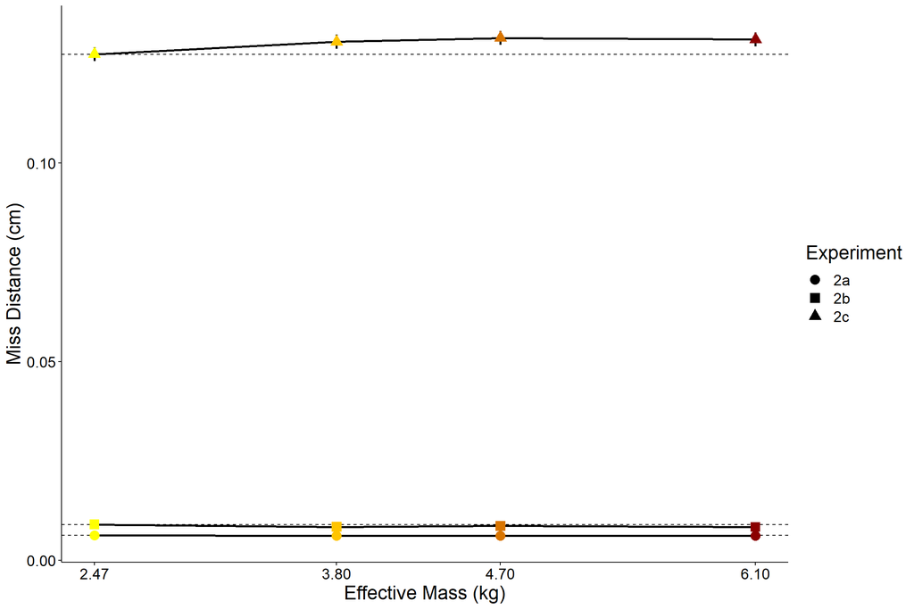

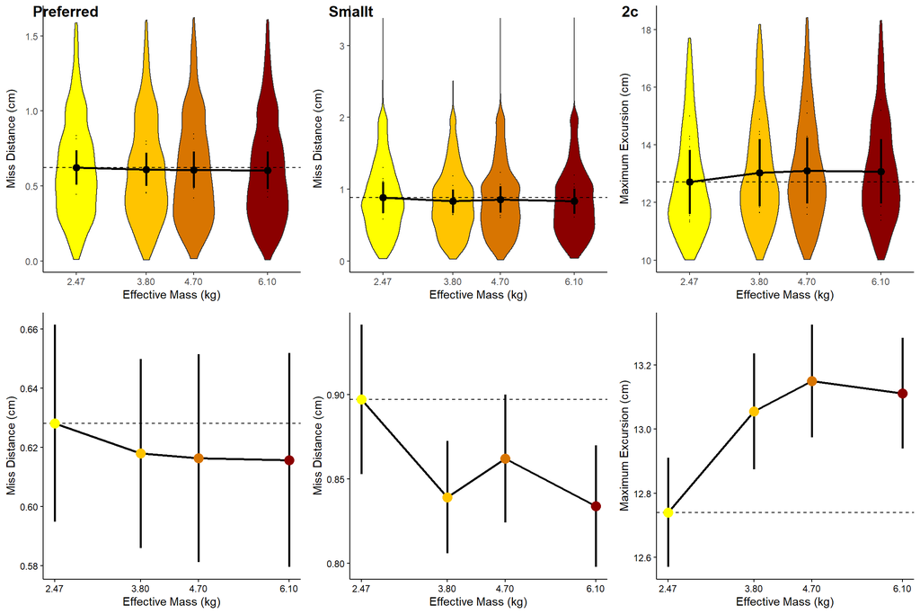

## 1.6 Angular Variance

Table 1.5: Miss Distance linear models.

| Miss Distance | Linear Estimate | P-Value | Std Error |
| --- | --- | --- | --- |
| Circle | 9.021e-02 | 2.331e-01 | 7.565e-02 |
| Pilot | 6.775e-01 | 7.504e-01 | 2.130e+00 |
| Arc | -4.072e-01 | 5.259e-01 | 6.420e-01 |
| All | 1.998e-01 | 8.294e-01 | 9.270e-01 |

Table 1.5: Miss Angle Variance average values (deg^2)

| Effective Mass (kg) | 2a | 2b | 2c |
| --- | --- | --- | --- |
| 2.5 | 2.988±0.375 | 19.59±4.591 | 82.775±14.702 |
| 3.8 | 2.551±0.238 | 15.455±2.954 | 92.356±23.995 |
| 4.7 | 3.023±0.299 | 19.224±4.053 | 89.809±18.937 |
| 6.1 | 3.212±0.267 | 17.067±3.091 | 86.145±16.938 |

```
##
##   Simultaneous Tests for General Linear Hypotheses
##
## Fit: lmer(formula = missangle ~ eff_mass * factor(exp) + (1 | subj),
##     data = var_data)
##
## Linear Hypotheses:
##                                 Estimate Std. Error z value Pr(>|z|)
## (Intercept) == 0                 2.55856   16.67940   0.153 0.878086
## eff_mass == 0                    0.09021    1.74656   0.052 0.958807
## factor(exp)smallt == 0          17.01325   23.58824   0.721 0.470750
## factor(exp)pilot == 0           82.32164   21.53302   3.823 0.000132 ***
## eff_mass:factor(exp)smallt == 0 -0.49741    2.47000  -0.201 0.840400
## eff_mass:factor(exp)pilot == 0   0.58730    2.25480   0.260 0.794505
## ---
## Signif. codes:  0 '***' 0.001 '**' 0.01 '*' 0.05 '.' 0.1 ' ' 1
## (Univariate p values reported)
```

There is NOT an overall effect of mass on miss angle variance (p = 9.588e-01).

Experiment 2b miss angle variance is not different from 2a (p = 4.707e-01).

Experiment 2c miss angle variance is significantly greater than 2a (slope = 8.232e+01, p = 1.318e-04).

The interesting thing with these are the interaction effects.

Experiment 2c miss angle variance did NOT change with mass more than 2a. (p = 7.945e-01).

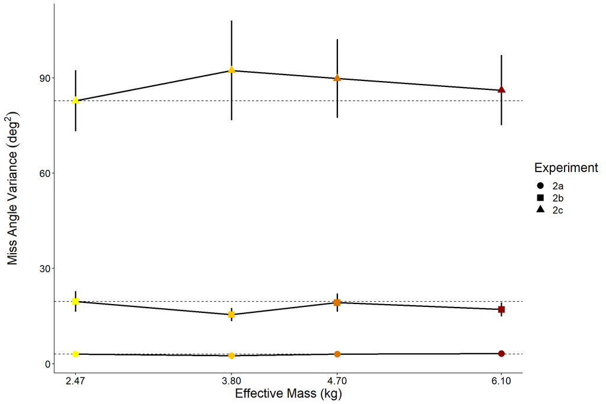

Figure 1.10: Miss Angle Variance (deg^2) by experiment.

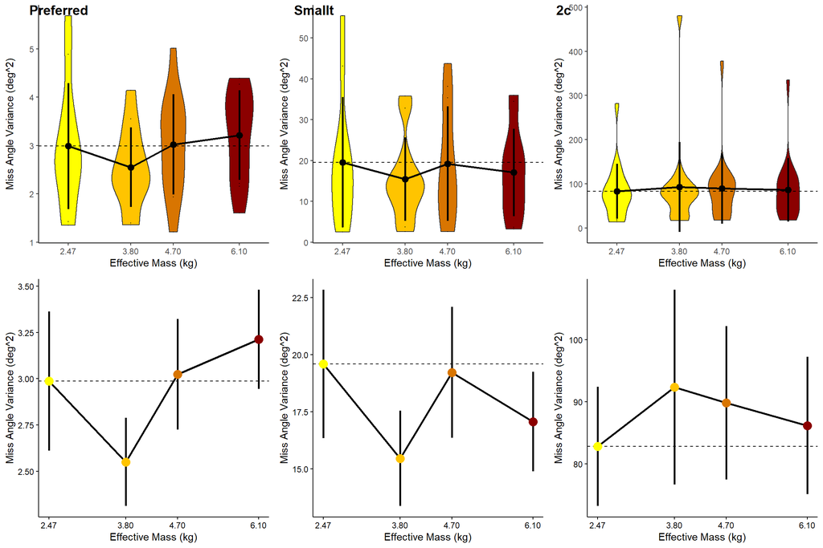

Figure 1.11: Miss Angle Variance (deg^2) broken by experiment.

## 1.7 Radial Variance

Table 1.6: Miss Distance Radial Variance (cm^2) linear models.

| Miss Distance | Linear Estimate | P-Value | Std Error |
| --- | --- | --- | --- |
| Circle | -4.307e-03 | 2.749e-01 | 3.944e-03 |
| Pilot | 2.582e-01 | 3.343e-03 | 8.798e-02 |
| Arc | -4.993e-03 | 8.036e-02 | 2.855e-03 |
| All | 1.080e-01 | 5.990e-03 | 3.929e-02 |

Table 1.6: Miss Radial Variance average values (cm^2)

| Effective Mass (kg) | 2a | 2b | 2c |
| --- | --- | --- | --- |
| 2.5 | 0.2651±0.0148 | 0.2339±0.0164 | 1.4368±0.5526 |
| 3.8 | 0.2529±0.0131 | 0.2227±0.015 | 1.9259±0.586 |
| 4.7 | 0.25±0.0142 | 0.2159±0.0153 | 2.1909±0.4874 |
| 6.1 | 0.2492±0.0208 | 0.2162±0.0127 | 2.369±0.471 |

There is NOT an overall effect of mass on miss radial variance (p = 9.515e-01).

Experiment 2b miss radial variance is not different from 2a (p = 9.668e-01).

Experiment 2c miss radial variance is not different from 2a (p = 3.429e-01).

The interesting thing with these are the interaction effects.

Experiment 2b miss radial variance did NOT change with mass more than 2a. (p = 9.945e-01).

Experiment 2c miss radial variance increases with mass more than experiment 2a (slope = 2.625e-01, p = 4.074e-03).

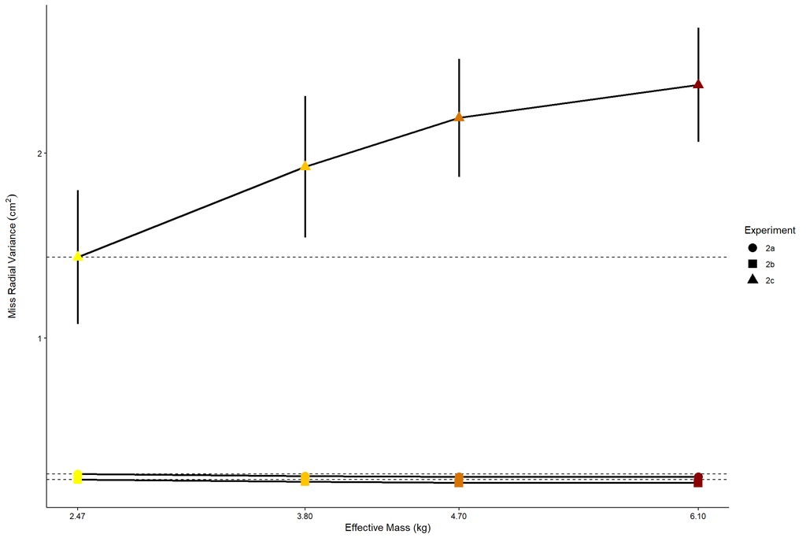

Figure 1.12: Miss Radial Variance by experiment.

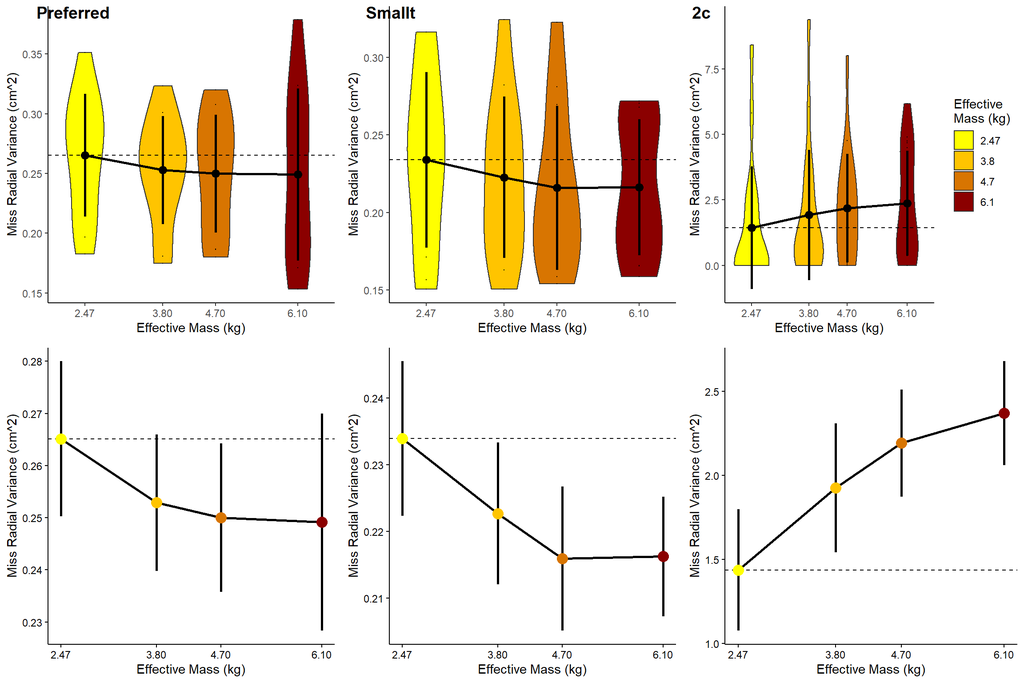

Figure 1.13: Miss Rad Variance (cm^2) broken by experiment.

## 1.8 Resample Plots

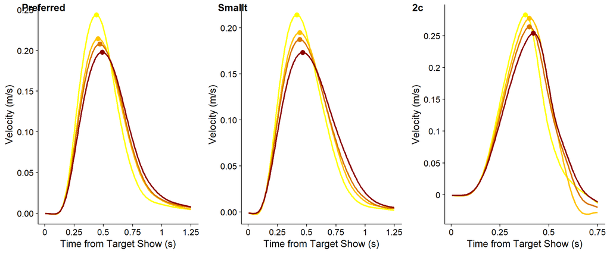

Figure 1.14: Velocity trajectories by experiment.

## 1.9 Preferred Experiment Grouped Plots

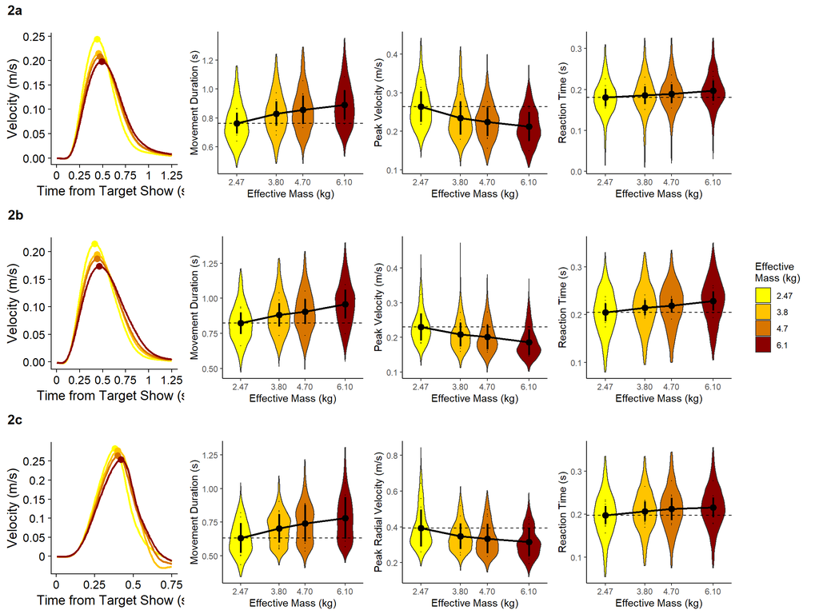

Figure 1.15: Preferred experiment results.

# 2 Metabolics Experiment

We filtered the metabolic data and removed any trial where the miss distance at endpoint was greater than 10 cm, the movement duration was less than 0.2 seconds, or the reaction time was greater than 0.50 s.This removed 13 out of 15975 original data poitns.

### 2.0.1 Speed on speed

```
## Analysis of Variance Table
##
## Response: movedur
##              Df  Sum Sq Mean Sq    F value Pr(>F)
## speed         1 1099.40 1099.40 1.0453e+05 <2e-16 ***
## eff_mass2     1    0.01    0.01 6.3430e-01 0.4258
## Residuals 15959  167.85    0.01
## ---
## Signif. codes:  0 '***' 0.001 '**' 0.01 '*' 0.05 '.' 0.1 ' ' 1
```

```
##
##   Simultaneous Tests for General Linear Hypotheses
##
## Fit: lmer(formula = movedur ~ speed + eff_mass2 + (1 | subj), data = metdata_factor)
##
## Linear Hypotheses:
##                   Estimate Std. Error z value Pr(>|z|)
## (Intercept) == 0 2.498e-01  8.172e-03  30.571   <2e-16 ***
## speed == 0       1.544e-01  4.760e-04 324.257   <2e-16 ***
## eff_mass2 == 0   5.641e-06  2.371e-04   0.024    0.981
## ---
## Signif. codes:  0 '***' 0.001 '**' 0.01 '*' 0.05 '.' 0.1 ' ' 1
## (Univariate p values reported)
```

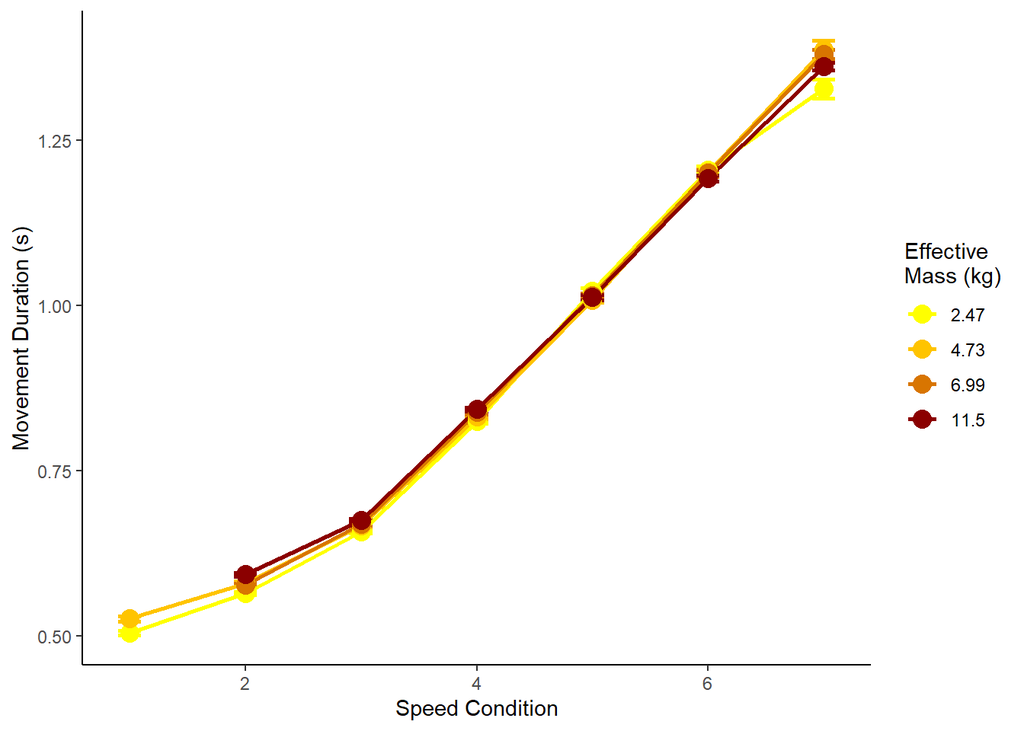

## 2.1 MP Gross

```
##
##   Simultaneous Tests for General Linear Hypotheses
##
## Fit: lmer(formula = log(metpowergross) ~ log(movedur) + effmass2 +
##     (1 | subject), data = mpdata)
##
## Linear Hypotheses:
##                    Estimate Std. Error z value Pr(>|z|)
## (Intercept) == 0   4.561517   0.066021  69.092  < 2e-16 ***
## log(movedur) == 0 -0.766794   0.037690 -20.345  < 2e-16 ***
## effmass2 == 0      0.017373   0.003369   5.156 2.52e-07 ***
## ---
## Signif. codes:  0 '***' 0.001 '**' 0.01 '*' 0.05 '.' 0.1 ' ' 1
## (Univariate p values reported)
```

Table 2.1: Gross Metabolic power plus/minus standard error for the metabolic experiment

|  | Speed = 1 | Speed = 2 | Speed = 3 | Speed = 4 | Speed = 5 | Speed = 6 | Speed = 7 |
| --- | --- | --- | --- | --- | --- | --- | --- |
| 2.73 kg | 171.9775 ± 18.515 | 131.625 ± 14.3282 | 110.1838 ± 5.8343 | 98.8513 ± 7.9976 | 105.3988 ± 8.8935 | 99.835 ± 7.0959 | NaN ± NA |
| 4.73 kg | 187.4712 ± 17.3187 | 153.6538 ± 13.0638 | 126.0213 ± 8.2191 | 104.4825 ± 6.9769 | 97.5825 ± 7.3818 | 97.2367 ± 5.4622 | NaN ± NA |
| 6.99 kg | NaN ± NA | 185.5288 ± 19.5249 | 140.2988 ± 11.6277 | 112.705 ± 6.8381 | 109.9457 ± 8.6896 | 98.7512 ± 7.5674 | 93.9237 ± 7.265 |
| 11.50 kg | NaN ± NA | 222.0613 ± 24.3934 | 155.0838 ± 13.5348 | 117.4025 ± 10.6555 | 110.285 ± 10.4558 | 96.8337 ± 5.2816 | 92.7812 ± 6.6335 |

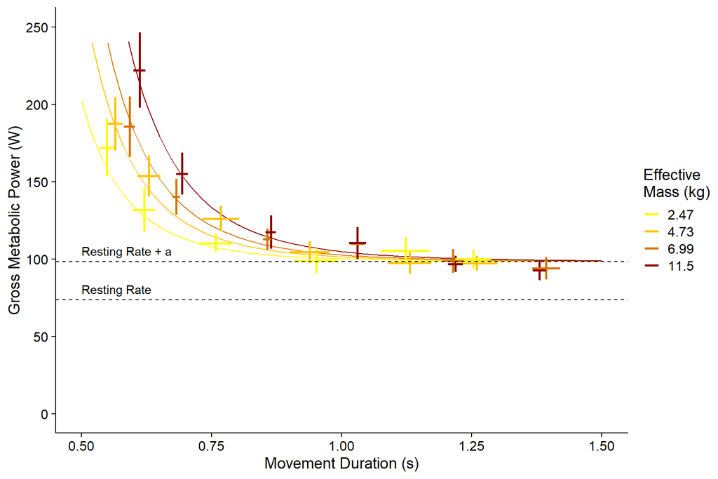

Figure 2.1: Gross metabolic power.

Parameter estimates are showing as mean +- standard error. The columns are for without the subject mass coefficient, and with a mass coefficient on the effort model. Subj Mass Coef is the subject mass exponent.

The no_mass_coef model is as follows:
$$\dot{e} = a+\frac{bm^c}{T_m^d}$$

The Subject mass model times a1 is as follows:
$$\dot{e} = a*Body Mass^{f}+\frac{bm^c}{T_m^d}$$

The effective mass model times a1 is as follows:
$$\dot{e} = a*Effective\, Mass^{f}+\frac{bm^c}{T_m^d}$$

Table 2.2: Gross metabolic power coefficients.

|  | a only | a*subject mass | a*effective mass |
| --- | --- | --- | --- |
| a | 98.2501±3.0512 | 22.0844±13.6907 | 101.4027±7.5926 |
| b | 0.864±0.4319 | 0.8593±0.4234 | 0.8375±0.4215 |
| c | 0.8308±0.0998 | 0.8247±0.0981 | 0.8548±0.1107 |
| d | 5.8254±0.603 | 5.8562±0.5956 | 5.8035±0.6061 |
| f | null | 0.2983±0.1232 | -0.0187±0.0411 |
| SSE | 120872.749595644 | 116826.723834405 | 120743.074844557 |
| AIC | 1750.832 | 1746.4653 | 1752.6313 |
| BIC | 1766.9875 | 1765.852 | 1772.0179 |

## 2.2 MP net

```
##
##   Simultaneous Tests for General Linear Hypotheses
##
## Fit: lmer(formula = log(metpowernet) ~ log(movedur) + effmass2 + (1 |
##     subject), data = mpdata)
##
## Linear Hypotheses:
##                   Estimate Std. Error z value Pr(>|z|)
## (Intercept) == 0   2.85218    0.23454  12.161  < 2e-16 ***
## log(movedur) == 0 -2.37941    0.16610 -14.326  < 2e-16 ***
## effmass2 == 0      0.04912    0.01485   3.308  0.00094 ***
## ---
## Signif. codes:  0 '***' 0.001 '**' 0.01 '*' 0.05 '.' 0.1 ' ' 1
## (Univariate p values reported)
```

Table 2.3: Net Metabolic power plus/minus standard error for the metabolic experiment

|  | Speed = 1 | Speed = 2 | Speed = 3 | Speed = 4 | Speed = 5 | Speed = 6 | Speed = 7 |
| --- | --- | --- | --- | --- | --- | --- | --- |
| 2.73 kg | 99.075 ± 17.3755 | 57.7875 ± 15.0154 | 36.3125 ± 5.9248 | 24.9875 ± 6.1351 | 31.5325 ± 8.1858 | 27.9333 ± 5.6508 | NaN ± NA |
| 4.73 kg | 113.7375 ± 18.2929 | 79.9875 ± 13.8077 | 52.3875 ± 8.9795 | 30.8212 ± 5.8168 | 23.9213 ± 7.2462 | 24.4667 ± 4.0208 | NaN ± NA |
| 6.99 kg | NaN ± NA | 111.7875 ± 19.9953 | 65.4 ± 11.9993 | 37.8638 ± 7.2397 | 37.7043 ± 7.8668 | 23.8963 ± 6.5959 | 19.0538 ± 6.8651 |
| 11.50 kg | NaN ± NA | 150.475 ± 22.0585 | 83.35 ± 13.048 | 45.6812 ± 10.4043 | 38.5625 ± 9.4318 | 25.0825 ± 5.0728 | 21.0525 ± 5.3099 |

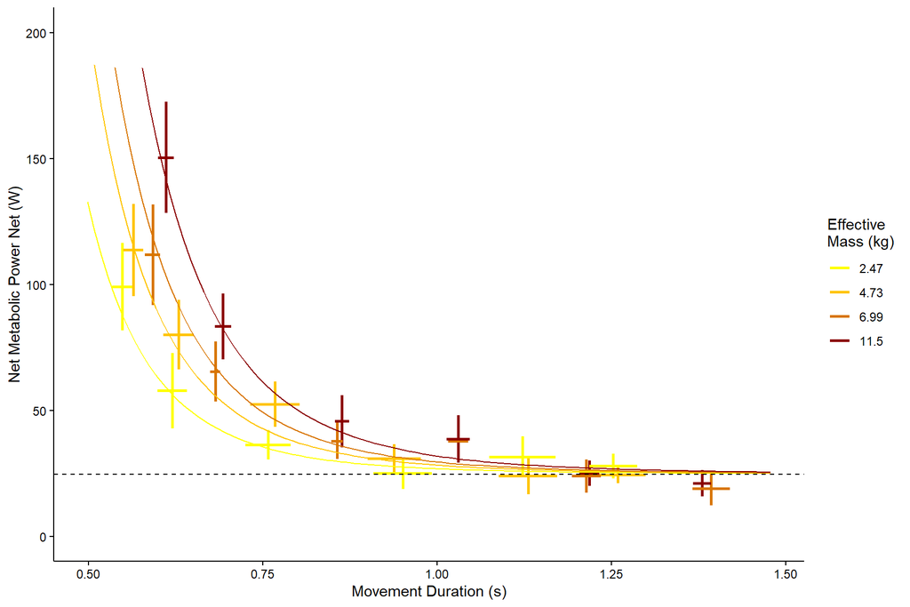

Figure 2.2: Net metabolic power.

Parameter estimates are showing as mean +- standard error. The columns are for without the subject mass coefficient, and with a mass coefficient on the effort model. Subj Mass Coef is the subject mass exponent.

The no_mass_coef model is as follows:
$$\dot{e} = a+\frac{bm^c}{T_m^d}$$

The Subject mass model times a1 is as follows:
$$\dot{e} = a*Body Mass^{f}+\frac{bm^c}{T_m^d}$$

The effective mass model times a1 is as follows:
$$\dot{e} = a*Effective\, Mass^{f}+\frac{bm^c}{T_m^d}$$

Table 2.4: Net metabolic power coefficients.

|  | a only | a*subject mass | a*effective mass |
| --- | --- | --- | --- |
| a | 24.7227±2.9124 | 0.1006±0.2368 | 24.0136±7.0228 |
| b | 1.0308±0.467 | 1.0007±0.4474 | 1.031±0.4707 |
| c | 0.7964±0.0904 | 0.7942±0.089 | 0.7962±0.1007 |
| d | 5.6574±0.5473 | 5.7151±0.5413 | 5.6575±0.5519 |
| f | null | 1.0939±0.4615 | 5e-04±0.1585 |
| SSE | 105365.400000357 | 101455.132835216 | 105365.395173997 |
| AIC | 1725.1562 | 1720.0843 | 1727.1561 |
| BIC | 1741.3117 | 1739.4709 | 1746.5428 |

## 2.3 MCost Gross

Table 2.5: Gross Metabolic Cost plus/minus standard error for the metabolic experiment

|  | Speed = 1 | Speed = 2 | Speed = 3 | Speed = 4 | Speed = 5 | Speed = 6 | Speed = 7 |
| --- | --- | --- | --- | --- | --- | --- | --- |
| 2.73 kg | 93.3222 ± 8.9748 | 80.1472 ± 7.2013 | 82.5764 ± 3.4054 | 94.0607 ± 9.0851 | 117.4043 ± 9.7673 | 125.4443 ± 10.8215 | NaN ± NA |
| 4.73 kg | 104.3653 ± 7.7764 | 95.0103 ± 5.6431 | 96.0467 ± 6.7137 | 97.5592 ± 7.0411 | 109.7052 ± 8.5622 | 123.3466 ± 10.6279 | NaN ± NA |
| 6.99 kg | NaN ± NA | 108.7596 ± 10.3474 | 95.2653 ± 7.1374 | 96.7068 ± 6.2899 | 113.0375 ± 8.3502 | 120.2383 ± 9.9578 | 130.8822 ± 10.7193 |
| 11.50 kg | NaN ± NA | 134.6313 ± 12.7635 | 106.7865 ± 8.1232 | 101.0186 ± 8.5022 | 112.9603 ± 9.2217 | 118.1752 ± 7.0501 | 128.0428 ± 9.1786 |

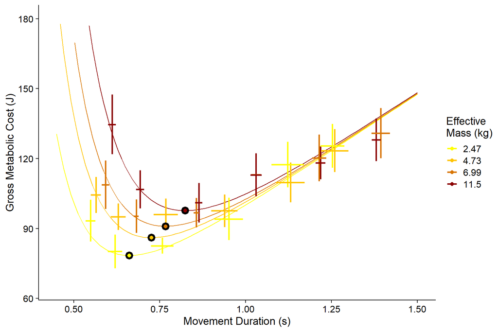

Figure 2.3: Gross metabolic cost.

The linear slope of the metabolic minimum is 0.0173807.

The optimal movement durations using the preferred masses are shown below along with the average movement durations.

Table 2.6: Minimum Cost durations for gross metabolic cost.

|  | Effective Mass (kg) | Minimum Cost (J) | Minimum Cost Duration (s) | Preferred Duraiton (s) |
| --- | --- | --- | --- | --- |
| a1 | 2.471 | 78.44419 | 0.6613455 | 0.7638165 |
| a1 | 3.800 | 83.41499 | 0.7032816 | 0.8299896 |
| a1 | 4.700 | 85.98258 | 0.7249254 | 0.8559532 |
| a1 | 6.100 | 89.24014 | 0.7523910 | 0.8902248 |

## 2.4 MCost Net

Table 2.7: Net Metabolic Cost plus/minus standard error for the metabolic experiment

|  | Speed = 1 | Speed = 2 | Speed = 3 | Speed = 4 | Speed = 5 | Speed = 6 | Speed = 7 |
| --- | --- | --- | --- | --- | --- | --- | --- |
| 2.73 kg | 53.1932 ± 8.5657 | 34.0816 ± 8.4267 | 26.267 ± 3.4663 | 23.2311 ± 5.6268 | 33.9323 ± 8.6921 | 35.0672 ± 7.0593 | NaN ± NA |
| 4.73 kg | 62.5789 ± 9.018 | 48.3557 ± 6.9453 | 39.0854 ± 6.5272 | 27.9088 ± 5.0761 | 25.9021 ± 7.7596 | 31.196 ± 5.3426 | NaN ± NA |
| 6.99 kg | NaN ± NA | 65.0537 ± 11.2371 | 44.2351 ± 7.8498 | 32.5745 ± 6.4326 | 38.6832 ± 7.8991 | 29.137 ± 8.1055 | 26.4202 ± 9.651 |
| 11.50 kg | NaN ± NA | 90.9807 ± 11.7824 | 57.0999 ± 8.418 | 39.0674 ± 8.6669 | 38.9813 ± 8.9591 | 30.4859 ± 6.2224 | 28.82 ± 7.2275 |

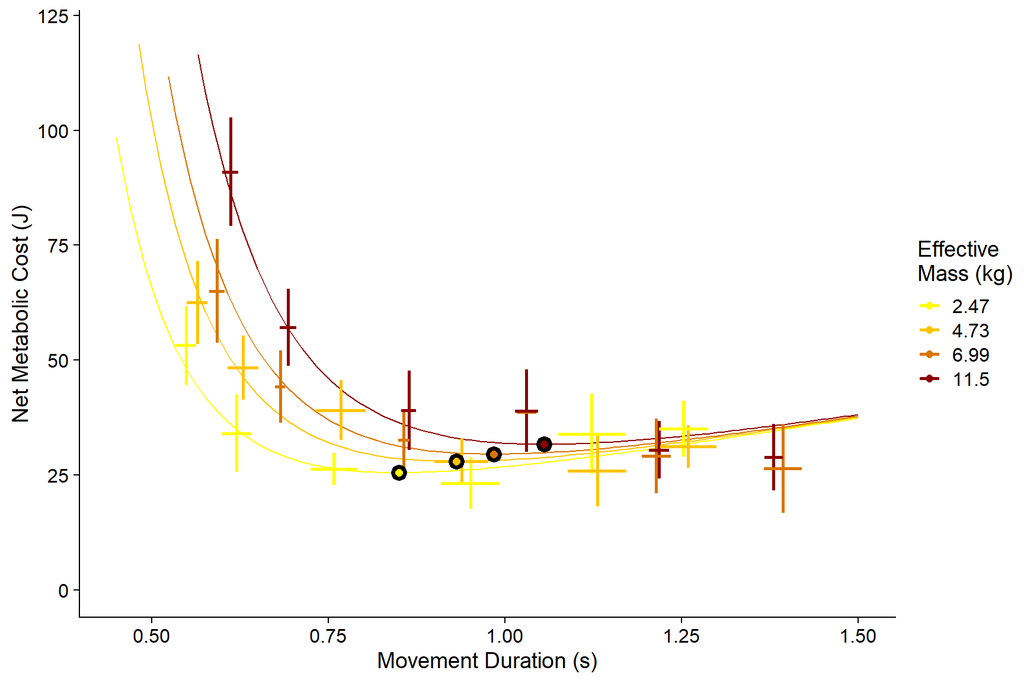

Figure 2.4: Net metabolic cost.

The optimal movement durations using the preferred masses are shown below along with the average movement durations.

Table 2.8: Minimum Cost durations for net metabolic cost.

|  | Effective Mass (kg) | Minimum Cost (J) | Minimum Cost Duration (s) | Preferred Duraiton (s) |
| --- | --- | --- | --- | --- |
| a1 | 2.471 | 25.52908 | 0.8500727 | 0.7638165 |
| a1 | 3.800 | 27.12511 | 0.9032332 | 0.8299896 |
| a1 | 4.700 | 27.94902 | 0.9306663 | 0.8559532 |
| a1 | 6.100 | 28.99388 | 0.9654625 | 0.8902248 |

## 2.5 Table of Movement Durations

Table 2.9: Movement Duration plus/minus standard error for the metabolic experiment

|  | Speed = 1 | Speed = 2 | Speed = 3 | Speed = 4 | Speed = 5 | Speed = 6 | Speed = 7 |
| --- | --- | --- | --- | --- | --- | --- | --- |
| 2.73 kg | 0.5486 ± 0.014 | 0.6202 ± 0.0211 | 0.7576 ± 0.0325 | 0.951 ± 0.0419 | 1.1227 ± 0.0476 | 1.2528 ± 0.04 | NaN ± NA |
| 4.73 kg | 0.5644 ± 0.0145 | 0.6295 ± 0.0219 | 0.7677 ± 0.0355 | 0.9386 ± 0.0381 | 1.1305 ± 0.0416 | 1.2593 ± 0.0459 | NaN ± NA |
| 6.99 kg | NaN ± NA | 0.5921 ± 0.011 | 0.6819 ± 0.007 | 0.8569 ± 0.0082 | 1.0306 ± 0.0152 | 1.2143 ± 0.0205 | 1.3931 ± 0.0269 |
| 11.50 kg | NaN ± NA | 0.6114 ± 0.0113 | 0.6931 ± 0.0115 | 0.8638 ± 0.0102 | 1.0304 ± 0.0163 | 1.2184 ± 0.0144 | 1.38 ± 0.013 |

## 2.6 Endpoint Error

```
##
##   Simultaneous Tests for General Linear Hypotheses
##
## Fit: lmer(formula = log(miss_dist) ~ log(movedur) + eff_mass2 + (1 |
##     subj), data = metdata)
##
## Linear Hypotheses:
##                    Estimate Std. Error z value Pr(>|z|)
## (Intercept) == 0  -5.529646   0.058862  -93.94   <2e-16 ***
## log(movedur) == 0 -0.937237   0.017751  -52.80   <2e-16 ***
## eff_mass2 == 0     0.021596   0.001683   12.83   <2e-16 ***
## ---
## Signif. codes:  0 '***' 0.001 '**' 0.01 '*' 0.05 '.' 0.1 ' ' 1
## (Univariate p values reported)
```

Table 2.10: Endpoitn Error plus/minus standard error for the metabolic experiment

|  | Speed = 1 | Speed = 2 | Speed = 3 | Speed = 4 | Speed = 5 | Speed = 6 | Speed = 7 |
| --- | --- | --- | --- | --- | --- | --- | --- |
| 2.73 kg | 0.0118 ± 3e-04 | 0.0084 ± 2e-04 | 0.0075 ± 2e-04 | 0.0056 ± 1e-04 | 0.0047 ± 1e-04 | 0.0046 ± 1e-04 | 0.0052 ± 3e-04 |
| 4.73 kg | 0.0129 ± 4e-04 | 0.0094 ± 2e-04 | 0.0075 ± 1e-04 | 0.0065 ± 1e-04 | 0.0052 ± 1e-04 | 0.005 ± 1e-04 | 0.0055 ± 3e-04 |
| 6.99 kg | NaN ± NA | 0.0105 ± 2e-04 | 0.0088 ± 2e-04 | 0.0065 ± 1e-04 | 0.0051 ± 1e-04 | 0.0044 ± 1e-04 | 0.005 ± 1e-04 |
| 11.50 kg | NaN ± NA | 0.0122 ± 2e-04 | 0.0092 ± 2e-04 | 0.0067 ± 1e-04 | 0.0053 ± 1e-04 | 0.0045 ± 1e-04 | 0.0049 ± 1e-04 |

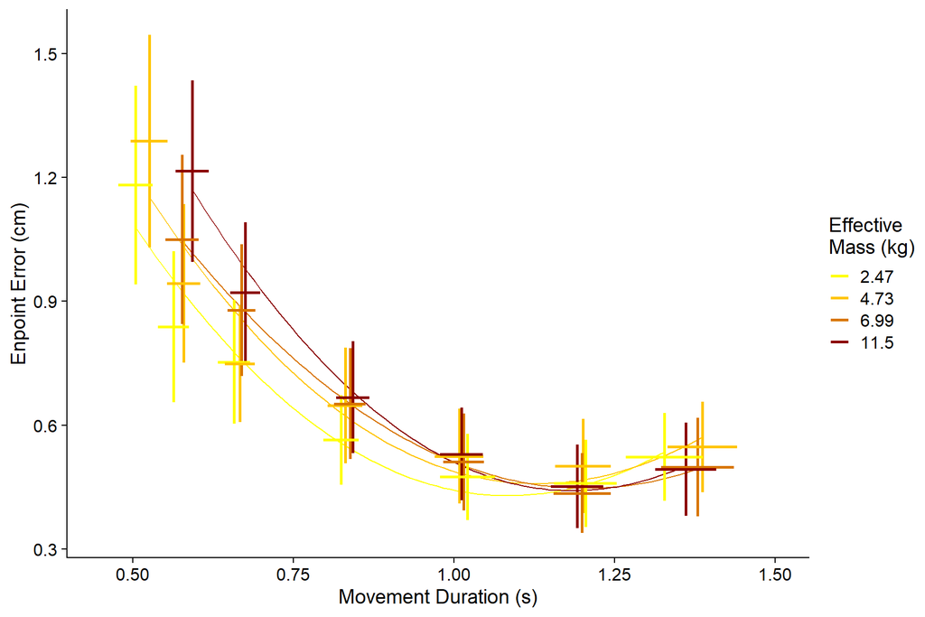

Figure 2.5: Endpoint Error.

## 2.7 Angle Variance

```
##
##   Simultaneous Tests for General Linear Hypotheses
##
## Fit: lmer(formula = log(missangle) ~ log(movedur) + eff_mass + (1 |
##     subj), data = c)
##
## Linear Hypotheses:
##                    Estimate Std. Error z value Pr(>|z|)
## (Intercept) == 0   0.724150   0.111106   6.518 7.14e-11 ***
## log(movedur) == 0 -1.140515   0.074456 -15.318  < 2e-16 ***
## eff_mass == 0      0.017424   0.006883   2.532   0.0114 *
## ---
## Signif. codes:  0 '***' 0.001 '**' 0.01 '*' 0.05 '.' 0.1 ' ' 1
## (Univariate p values reported)
```

[output not shown]

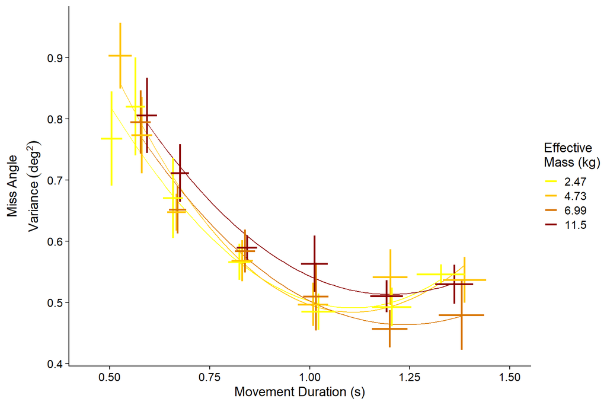

Figure 2.6: Angular miss variance.

## 2.8 Radial Endpoint Variance

```
##
##   Simultaneous Tests for General Linear Hypotheses
##
## Fit: lmer(formula = log(miss_rad) ~ log(movedur) + eff_mass + (1 |
##     subj), data = c)
##
## Linear Hypotheses:
##                     Estimate Std. Error  z value Pr(>|z|)
## (Intercept) == 0  -10.559873   0.086527 -122.041   <2e-16 ***
## log(movedur) == 0  -1.000083   0.070358  -14.214   <2e-16 ***
## eff_mass == 0      -0.006928   0.006506   -1.065    0.287
## ---
## Signif. codes:  0 '***' 0.001 '**' 0.01 '*' 0.05 '.' 0.1 ' ' 1
## (Univariate p values reported)
```

Table 2.12: Radial Endpoint Variance plus/minus standard error for the metabolic experiment

|  | Speed = 1 | Speed = 2 | Speed = 3 | Speed = 4 | Speed = 5 | Speed = 6 | Speed = 7 |
| --- | --- | --- | --- | --- | --- | --- | --- |
| 2.73 kg | 0.3286±,0.0772 | 0.2452±,0.0943 | 0.212±,0.056 | 0.1659±,0.0119 | 0.1802±,0.0322 | 0.1666±,0.0096 | 0.1983±,0.0012 |
| 4.73 kg | 0.3244±,0.0778 | 0.2426±,0.0473 | 0.1943±,0.0302 | 0.1928±,0.0334 | 0.1793±,0.023 | 0.1752±,0.012 | 0.183±,0.0184 |
| 6.99 kg | ±, | 0.2456±,0.0572 | 0.2012±,0.0684 | 0.1834±,0.0723 | 0.1603±,0.0278 | 0.1578±,0.014 | 0.1647±,0.0191 |
| 11.50 kg | ±, | 0.2745±,0.0397 | 0.1985±,0.013 | 0.1776±,0.0235 | 0.1613±,0.0264 | 0.1564±,0.0164 | 0.1619±,0.0177 |

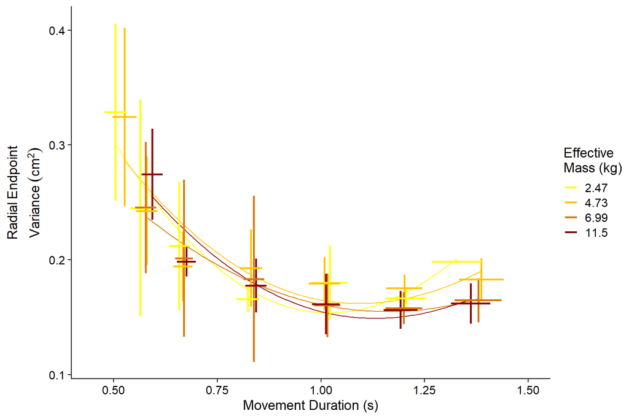

Figure 2.7: Radial miss variance.

## 2.9 Reaction Time

```
##
##   Simultaneous Tests for General Linear Hypotheses
##
## Fit: lmer(formula = reaction_tanv ~ log(movedur) + eff_mass2 + (1 |
##     subj), data = metdata)
##
## Linear Hypotheses:
##                    Estimate Std. Error z value Pr(>|z|)
## (Intercept) == 0  0.1585730  0.0071557   22.16   <2e-16 ***
## log(movedur) == 0 0.0530319  0.0012279   43.19   <2e-16 ***
## eff_mass2 == 0    0.0023967  0.0001164   20.59   <2e-16 ***
## ---
## Signif. codes:  0 '***' 0.001 '**' 0.01 '*' 0.05 '.' 0.1 ' ' 1
## (Univariate p values reported)
```

```
##
##   Simultaneous Tests for General Linear Hypotheses
##
## Fit: lmer(formula = reaction_tanv ~ movedur + eff_mass2 + (1 | subj),
##     data = metdata)
##
## Linear Hypotheses:
##                   Estimate Std. Error z value Pr(>|z|)
## (Intercept) == 0 0.0924072  0.0072719   12.71   <2e-16 ***
## movedur == 0     0.0643985  0.0014023   45.92   <2e-16 ***
## eff_mass2 == 0   0.0023962  0.0001155   20.75   <2e-16 ***
## ---
## Signif. codes:  0 '***' 0.001 '**' 0.01 '*' 0.05 '.' 0.1 ' ' 1
## (Univariate p values reported)
```

Table 2.13: Reaction time plus/minus standard error for the metabolic experiment

|  | Speed = 1 | Speed = 2 | Speed = 3 | Speed = 4 | Speed = 5 | Speed = 6 | Speed = 7 |
| --- | --- | --- | --- | --- | --- | --- | --- |
| 2.73 kg | 0.1123 ± 0.0028 | 0.1268 ± 0.002 | 0.1401 ± 0.0019 | 0.1547 ± 0.0017 | 0.1661 ± 0.0018 | 0.1757 ± 0.0021 | 0.1931 ± 0.0042 |
| 4.73 kg | 0.1325 ± 0.0027 | 0.1344 ± 0.002 | 0.1445 ± 0.0019 | 0.1623 ± 0.0016 | 0.1787 ± 0.0017 | 0.1922 ± 0.0018 | 0.2129 ± 0.0051 |
| 6.99 kg | NaN ± NA | 0.137 ± 0.002 | 0.1489 ± 0.0018 | 0.1671 ± 0.0018 | 0.1759 ± 0.0018 | 0.1938 ± 0.0019 | 0.2108 ± 0.0022 |
| 11.50 kg | NaN ± NA | 0.1446 ± 0.002 | 0.157 ± 0.0017 | 0.1699 ± 0.0019 | 0.1874 ± 0.0017 | 0.2021 ± 0.0019 | 0.2259 ± 0.0023 |

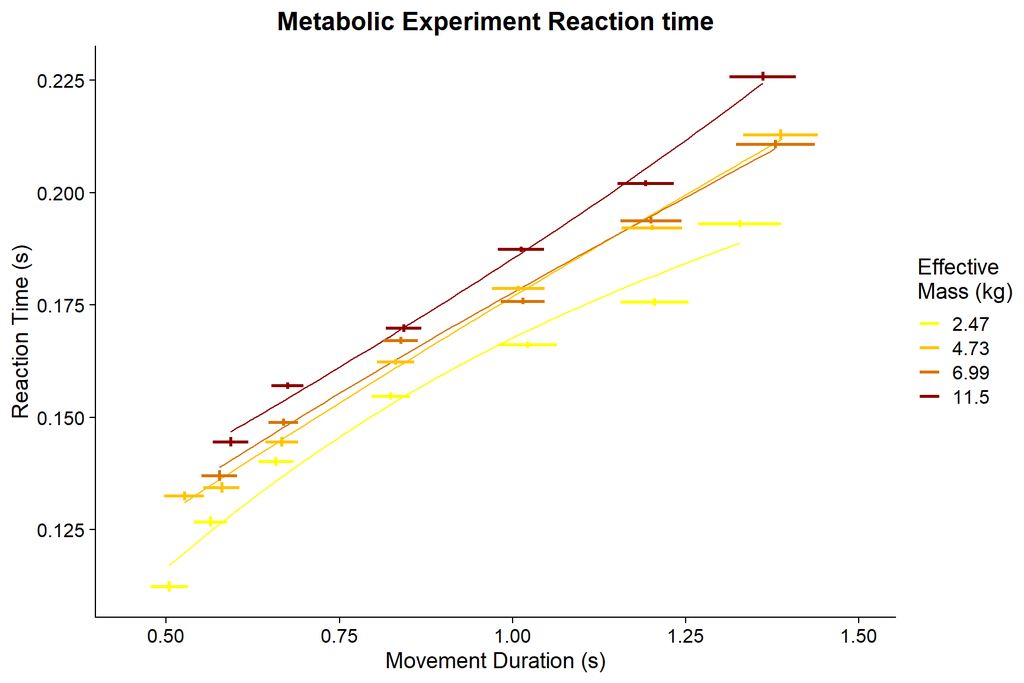

Figure 2.8: Reaction time in metabolic experiment.

## 2.10 Metabolic results plot

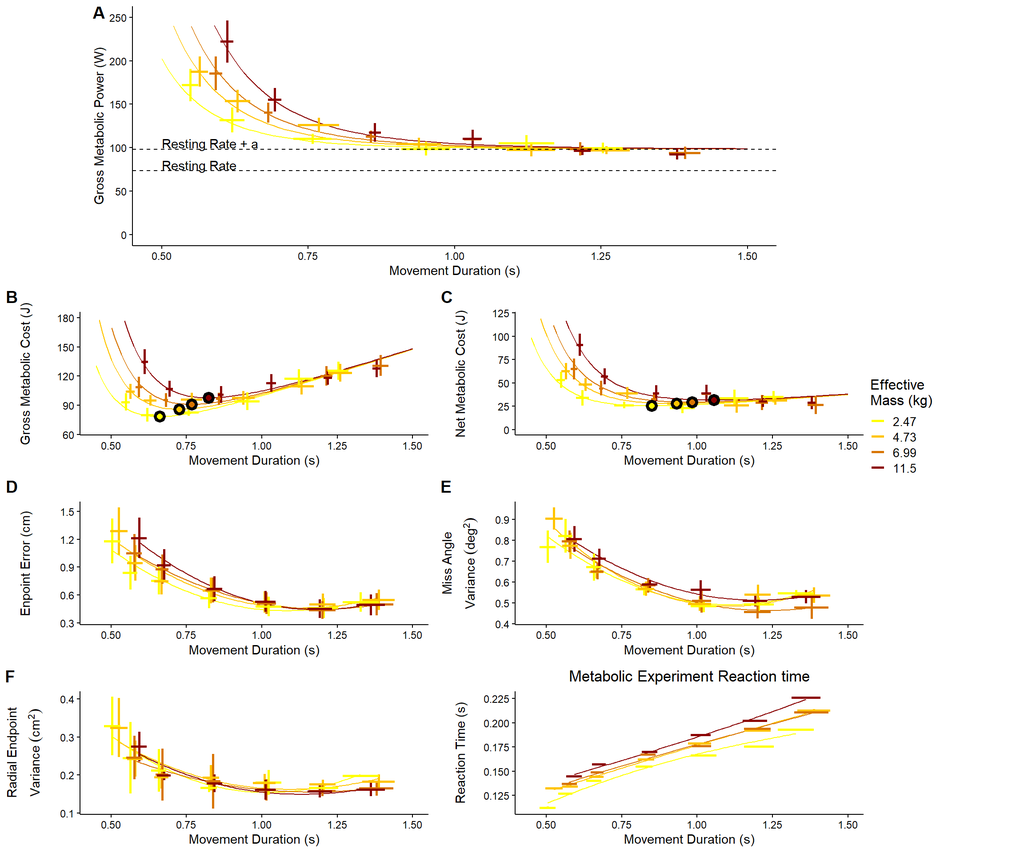

Figure 2.9: Metabolic experiment results.

# 3 Effort models

We compute 4 effort models here. Gross metabolics, net metabolics, and sum of torque squared (experimentally calculated and calcualted from minimum jerk). Net and gross metabolics have been addressed before, here we add sum of torque squared.

Sum of torque sqaured is calcualted from the data and simulated minimum jerk profiles and then fit to an effort model like net metabolic and gross metabolic power but without the a parameter.

$$\dot{e} = \frac{bm^c}{T_m^d}$$

## 3.1 Torque Squared

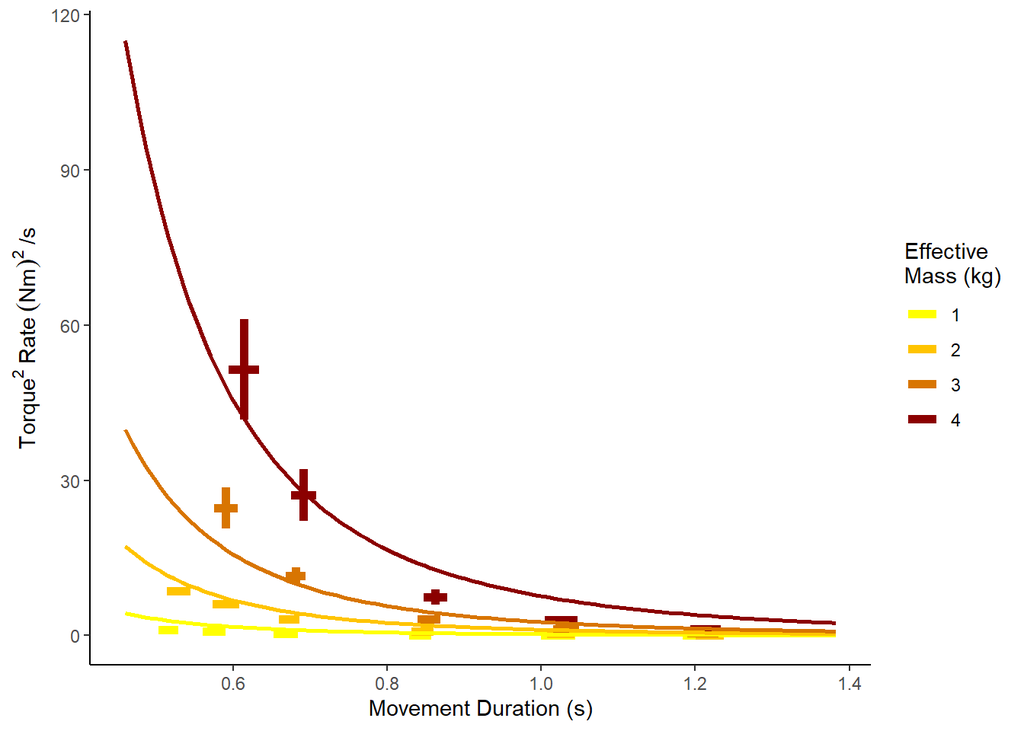

Figure 3.1: Sum of torque squared fits from the data

## 3.2 Effort model parameters

This table shows a summary of all the parameters that were fitted in the effort models. SSE, AIC, and BIC can be found in their respective sections.

Table 3.1: Parameters fit in the effort models.

|  | Net Metabolics | Gross Metabolics | Torque$^2$ | Torque$^2$ minjerk |
| --- | --- | --- | --- | --- |
| a0 | 73.3259±3.6041 | 73.3259±3.6041 | 0 | 0 |
| a | 24.0346 ± 2.9124 | 98.2501 ± 3.0512 | 0 | 0 |
| b | 1.0308 ± 0.467 | 0.864 ± 0.4319 | 0.0416 ± 0.0079 | 0.2885 ± 0.0429 |
| c | 0.7964 ± 0.0904 | 0.8308 ± 0.0998 | 2.1339 ± 0.0728 | 1.6071 ± 0.054 |
| d | 5.6574 ± 0.5473 | 5.8254 ± 0.603 | 3.4951 ± 0.1229 | 1.3379 ± 0.0249 |
| AIC | 1725.15615301424 | 1750.8320060654 | 9611.79628744657 | 35100.9080475733 |
| BIC | 1741.31169609851 | 1766.98754914967 | 9632.60990953091 | 35125.7853519489 |

### 3.2.1 Torque squared models with offset not forced to 0

Sum of torque sqaured is calcualted from the data and simulated minimum jerk profiles and then fit to an effort model like net metabolic and gross metabolic power. In these we allowed $a$ to be fit to see if it would predict a 0 offset.

$$\dot{e} = a+\frac{bm^c}{T_m^d}$$

Table 3.2: Confidence intervals for torque squared model.

|  | 2.5% | 97.5% |
| --- | --- | --- |
| a1 | -2.6747330 | -0.9462295 |
| a2 | 0.0553365 | 0.1392793 |
| a3 | 1.7512603 | 2.0645923 |
| a4 | 2.9486703 | 3.4315542 |

# 4 Probablity Modeling

The probability function for the 2a is:
$$ln\left(\frac{P_i}{1-P_i}\right) = \beta_0 + \beta_2 x_2$$
Which leads to
$$P(Success|T) = \frac{1}{1+e^{-(\beta_0) - (\beta_2)T}}$$
Mass is removed from this probability as according to the model it is insignificant. Duration nad mass alos condound here, so we only use duration. I leave it $\beta_2$ because that is more similar to the glm with mass from experiement 1.

We then use this function to first fit an inverse logit to experiment 2a and 2b. We then use the criteria for success and fit the same inverse logit function but using the data from experiment 1.

## 4.1 Probability of sucess in just 2a and 2b without 1

The following table shows the beta coefficients for the inverse logit function only predicting from experiment 2a and 2b.

Table 4.1: Beta coefficient for the inverse logit function to predict probability of success.

|  | 2a | 2b |
| --- | --- | --- |
| $\beta_0$ | 2.5791 ± 0.469 | 1.1985 ± 0.174 |
| $\beta_2$ | 1.6285 ± 0.575 | 0.4219 ± 0.193 |

Using these functions we can then predict the probability of success as a fraction of success given the data and using the logit model. The following table shows this for experiment 2a and 2b.

Table 4.2: Success probabilities for experiment 2a and 2b. Also predicted from glm fitted using data from 2a and 2b

|  | 2a | Predicted 2a | 2b | Predicted 2b |
| --- | --- | --- | --- | --- |
| 2.47 | 0.9782 | 0.9786 | 0.8110 | 0.8243 |
| 3.8 | 0.9839 | 0.9807 | 0.8537 | 0.8278 |
| 4.7 | 0.9779 | 0.9815 | 0.8167 | 0.8293 |
| 6.1 | 0.9815 | 0.9825 | 0.8318 | 0.8324 |

### 4.1.1 2a and 2b GLM probability plots

The plot below shows the fits of the glm’s fitted to only data from experiment 2a and 2b. Unfortunately, these glm’s don’t seem to have the same behavior as data fitted to experiment 1 of dropping off to 0 at faster speeds. This is probably due to the lack of really fast or really slow trials so it just predicts a flat line essentially.

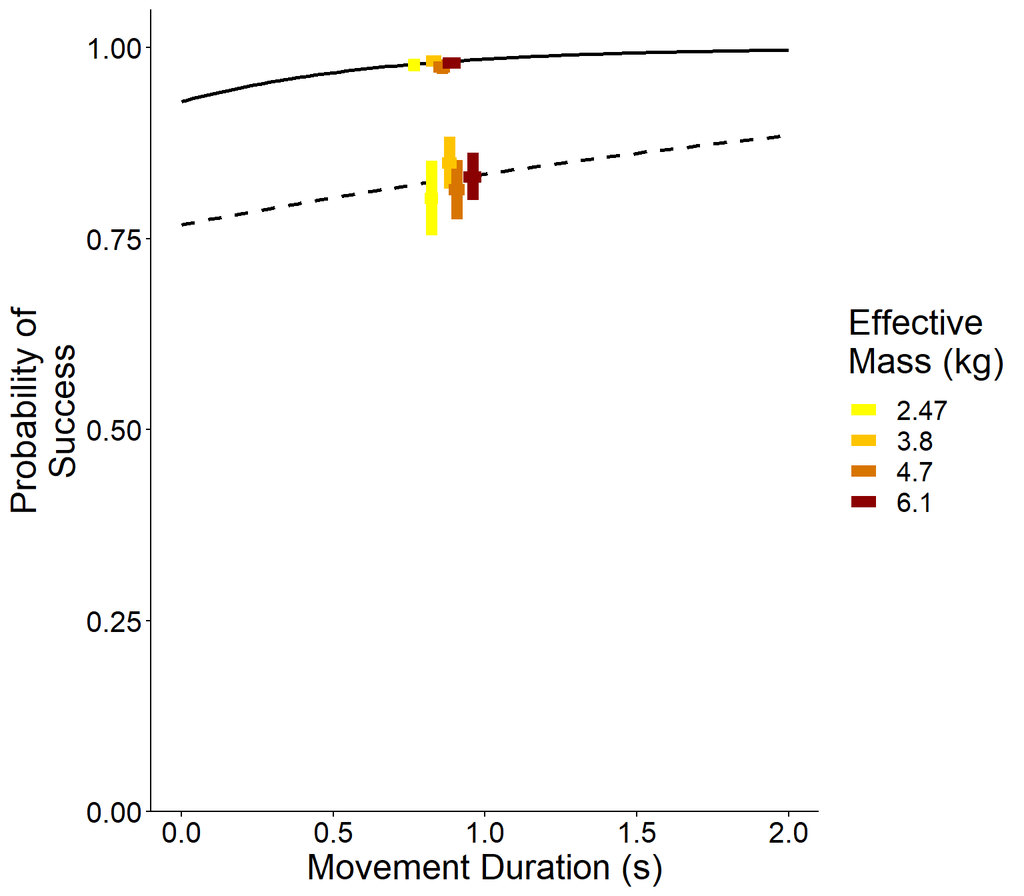

Figure 4.1: Probability of success with glm fitted to experiment 2a and 2b data.

### 4.1.2 Statistics on probability of success 2a

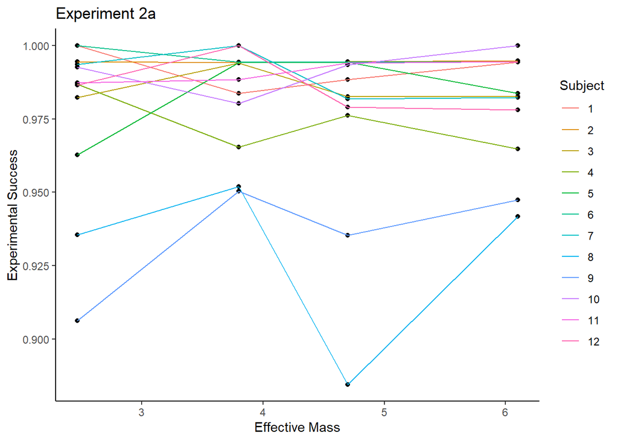

```
##
##   Simultaneous Tests for General Linear Hypotheses
##
## Fit: lmer(formula = success ~ eff_mass + (1 | subj), data = aggregate(success ~
##     eff_mass + subj, prefdata, mean))
##
## Linear Hypotheses:
##                   Estimate Std. Error z value Pr(>|z|)
## (Intercept) == 0 0.9781917  0.0089704 109.046   <2e-16 ***
## eff_mass == 0    0.0001357  0.0014250   0.095    0.924
## ---
## Signif. codes:  0 '***' 0.001 '**' 0.01 '*' 0.05 '.' 0.1 ' ' 1
## (Univariate p values reported)
```

### 4.1.3 Statistics on probability of success 2b

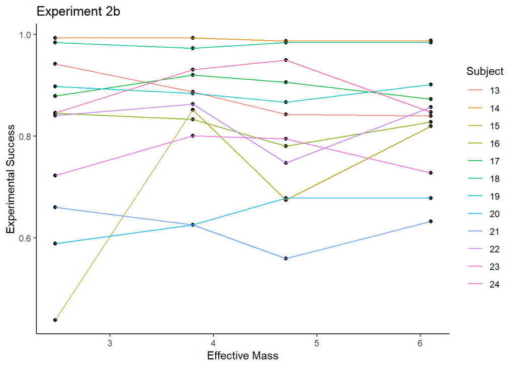

```
##
##   Simultaneous Tests for General Linear Hypotheses
##
## Fit: lmer(formula = success ~ eff_mass + (1 | subj), data = aggregate(success ~
##     eff_mass + subj, smalltdata, mean))
##
## Linear Hypotheses:
##                  Estimate Std. Error z value Pr(>|z|)
## (Intercept) == 0 0.803251   0.046611  17.233   <2e-16 ***
## eff_mass == 0    0.004996   0.007143   0.699    0.484
## ---
## Signif. codes:  0 '***' 0.001 '**' 0.01 '*' 0.05 '.' 0.1 ' ' 1
## (Univariate p values reported)
```

## 4.2 Probability of success using experiment 1

This table shows the beta coefficients when using an inverse logit on experiment 1 trying to predict 2a and 2b.

Table 4.3: Beta coefficient for the inverse logit function to predict probability of success.

|  | 2a | 2b |
| --- | --- | --- |
| $\beta_0$ | -1.4458 ± 0.125 | -2.5804 ± 0.077 |
| $\beta_1$ | -0.0966 ± 0.008 | -0.0641 ± 0.006 |
| $\beta_2$ | 5.8758 ± 0.188 | 4.8391 ± 0.1 |

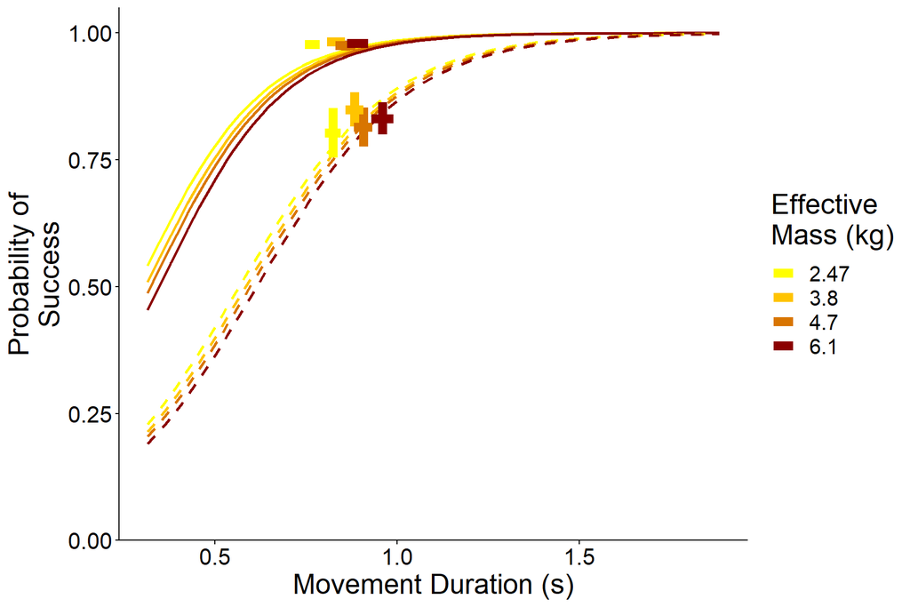

This plot includes low and high movement durations to show that the functions converge to 0 and 1 probability respectively.

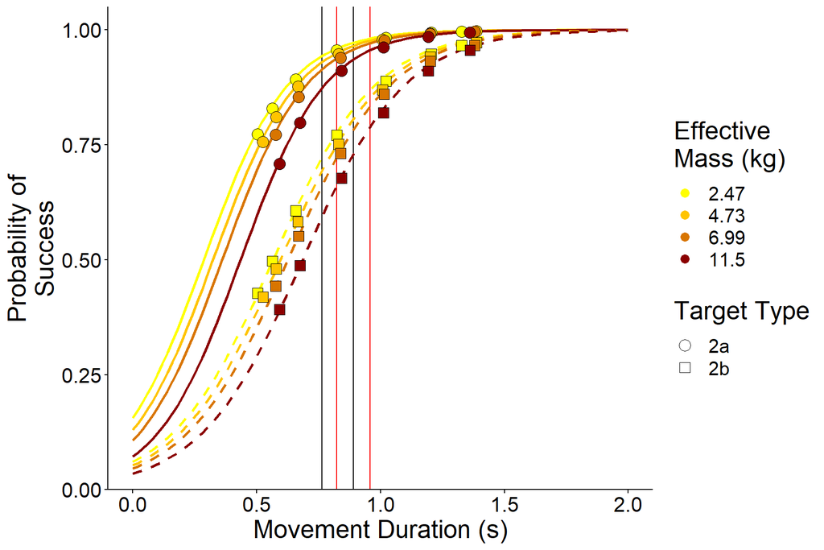

Figure 4.3: Probability of success given movement duration and mass. The black vertical bars show the range of durations for the 2a preferred exerpiement. The red vertical bars show the range of durations for the smallt target.

This next table shows the movement durations for experiment 2a and 2b, the probability of success from the experiment, along with the probability of success from the logistic regression. The last row is the mean probability.

|  | 2a Movedur | 2a Exp Prob | 2a Pred Prob | 2b Movedur | 2b Exp Prob | 2b Pred Prob |
| --- | --- | --- | --- | --- | --- | --- |
| 2.47 | 0.7638 | 0.9782 | 0.9429 | 0.8226 | 0.8110 | 0.7759 |
| 3.80 | 0.8300 | 0.9839 | 0.9554 | 0.8813 | 0.8537 | 0.8086 |
| 4.70 | 0.8560 | 0.9779 | 0.9581 | 0.9051 | 0.8167 | 0.8173 |
| 6.10 | 0.8902 | 0.9815 | 0.9607 | 0.9588 | 0.8318 | 0.8414 |
| Mean | NaN | 0.9804 | 0.9543 | NaN | 0.8283 | 0.8108 |